# PS5

Jeffery Zhang

2023-12-08

## ———- PS5: RMarkdown and Plotting ———-

```r
library(readr)
```

```r
library(ggplot2)
library(dplyr)
library(lubridate)
```

This is for library setup. Library lubridate helps to convert month/day format to day # of the year.

## 1.1.1

```r
nyc_flights <- read_delim("C:/Users/xuz-t/OneDrive/Documents/INFO_201_Scripts/PS5/data/nycflights.csv")
print(nyc_flights)
```

```
## # A tibble: 32,735 × 16
##     year month   day dep_time dep_delay arr_time arr_delay carrier tailnum
##    <dbl> <dbl> <dbl>    <dbl>     <dbl>    <dbl>     <dbl> <chr>   <chr>
##  1  2013     6    30      940        15     1216        -4 VX      N626VA
##  2  2013     5     7     1657        -3     2104        10 DL      N3760C
##  3  2013    12     8      859        -1     1238        11 DL      N712TW
##  4  2013     5    14     1841        -4     2122       -34 DL      N914DL
##  5  2013     7    21     1102        -3     1230        -8 9E      N823AY
##  6  2013     1     1     1817        -3     2008         3 AA      N3AXAA
##  7  2013    12     9     1259        14     1617        22 WN      N218WN
##  8  2013     8    13     1920        85     2032        71 B6      N284JB
##  9  2013     9    26      725       -10     1027        -8 AA      N3FSAA
## 10  2013     4    30     1323        62     1549        60 EV      N12163
## # ℹ 32,725 more rows
## # ℹ 7 more variables: flight <dbl>, origin <chr>, dest <chr>, air_time <dbl>,
## #   distance <dbl>, hour <dbl>, minute <dbl>
```

This is to extract data from the .csv file. Looks fine.

## 1.1.2

```r
codes_not_three_chars <- nyc_flights$origin[nchar(nyc_flights$dest) != 3]
codes_with_digits <- nyc_flights$origin[grepl("[0-9]", nyc_flights$dest)]
print(codes_not_three_chars)
```

```
## character(0)
```

```r
print(codes_with_digits)
```

```
## character(0)
```

No, there are no airport codes that either are not three characters long or contain digits.

## 1.1.3

```r
missing_arrival_delays <- sum(is.na(nyc_flights$arr_delay))
```

There are no missing arrival delay data. Therefore, it is not a problem for this data.

## 1.1.4

Checking the .csv file, there doesn’t seem to be any problematic values for the delay variable.

## 1.1.5

```r
average_delay_by_dest <- aggregate(arr_delay ~ dest, data = nyc_flights, FUN = function(x) mean(x, na.rm = TRUE))
sorted_destinations <- average_delay_by_dest[order(-average_delay_by_dest$arr_delay), ]
top_three_destinations <- head(sorted_destinations, 3)
worst_3_flights <- data.frame("Destination" =  top_three_destinations$dest, "AvgDelay" = top_three_destinations$arr_delay)
print(worst_3_flights)
```

```
##   Destination AvgDelay
## 1         CAE 53.33333
## 2         BHM 34.67647
## 3         OKC 30.37931
```

These are the destinations with the worst delay times.

## 1.1.6

```r
average_delay_by_month <- aggregate(arr_delay ~ month, data = nyc_flights, FUN = function(x) mean(x, na.rm = TRUE))
print(average_delay_by_month)
```

```
##    month  arr_delay
## 1      1  6.8344828
## 2      2  4.9632546
## 3      3  6.3164866
## 4      4 12.1341244
## 5      5  3.6455158
## 6      6 16.4853587
## 7      7 16.1484318
## 8      8  6.0361111
## 9      9 -4.0313316
## 10    10 -0.5488904
## 11    11  1.2499085
## 12    12 15.9734904
```

These are the average delays by month.

## 1.1.7

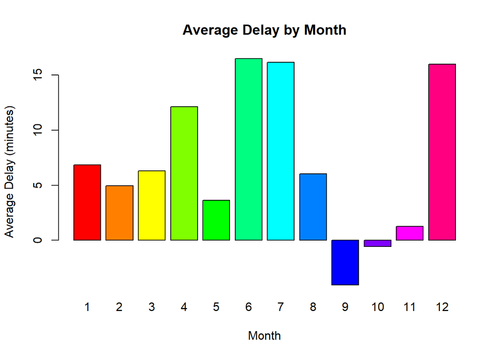

```r
bar_colors <- rainbow(12)
barplot(average_delay_by_month$arr_delay, names.arg = average_delay_by_month$month, col = bar_colors,
        main = "Average Delay by Month",
        xlab = "Month",
        ylab = "Average Delay (minutes)")
```

## 1.1.8

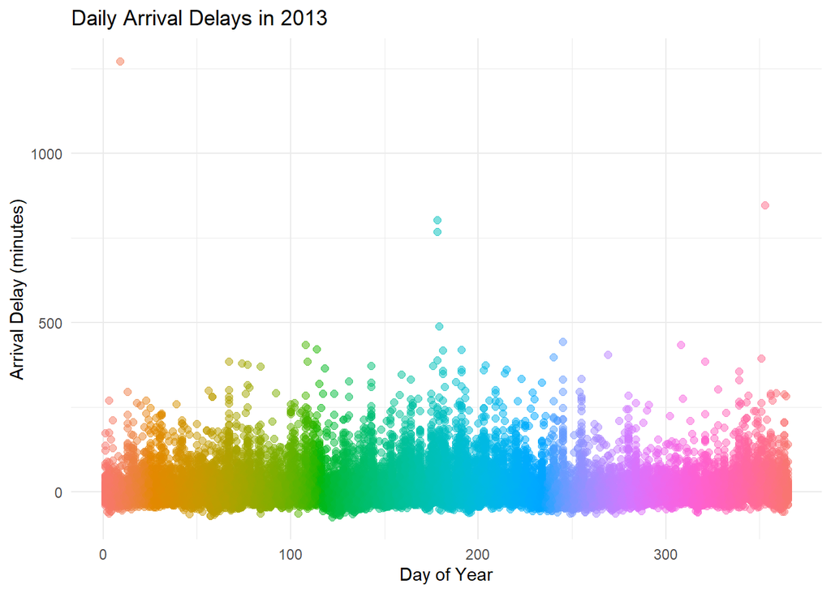

```r
nyc_flights <- nyc_flights %>%
  mutate(date = as.Date(paste(year, month, day, sep = "-")))
nyc_flights$day_of_year <- yday(nyc_flights$date)
average_delay_by_day <- aggregate(arr_delay ~ day_of_year, data = nyc_flights, FUN = function(x) mean(x, na.rm = TRUE))
ggplot(nyc_flights, aes(x = day_of_year, y = arr_delay, col = factor(day_of_year))) +
  geom_point(alpha = 0.5, size = 2, show.legend = FALSE) +
  labs(x = "Day of Year", y = "Arrival Delay (minutes)", title = "Daily Arrival Delays in 2013") +
  theme_minimal()
```

## ———- 1.2: Chicago ———-

## 1.2.1

```r
flights_to_ORD <- nyc_flights[nyc_flights$dest == "ORD", ]
num_flights_to_ORD <- nrow(flights_to_ORD)
cat(num_flights_to_ORD)
```

```
## 1588
```

This is the number of flights to Chicago.

## 1.2.2

```r
fastest_flight_index <- which.min(flights_to_ORD$air_time)
fastest_flight <- flights_to_ORD[fastest_flight_index, ]
cat("Departure date of the fastest flight: ", fastest_flight$month, "-", fastest_flight$day, "\n")
```

```
## Departure date of the fastest flight:  5 - 8
```

```r
cat("Departure time of the fastest flight: ", fastest_flight$dep_time, "\n")
```

```
## Departure time of the fastest flight:  1316
```

```r
cat("Air time of the fastest flight: ", fastest_flight$air_time, " minutes\n")
```

```
## Air time of the fastest flight:  92  minutes
```

```r
cat("Carrier of the fastest flight: ", fastest_flight$carrier, "\n")
```

```
## Carrier of the fastest flight:  MQ
```

```r
cat("Original airport of the fastest flight: ", fastest_flight$origin, "\n")
```

```
## Original airport of the fastest flight:  EWR
```

This is the fastest flight to Chicago and relevant information about the given flight.

## 1.2.3

According to Google Flights, it takes approximately 3 hours to fly from New York to Chicago. Therefore, 92 minutes (which is the flight time for this specific flight) doesn’t seem to be reasonable.

## 1.2.4

```r
slowest_flight_index <- which.max(flights_to_ORD$air_time)
slowest_flight <- flights_to_ORD[slowest_flight_index, ]
cat("Departure date of the slowest flight: ", slowest_flight$month, "-", fastest_flight$day, "\n")
```

```
## Departure date of the slowest flight:  4 - 8
```

```r
cat("Departure time of the slowest flight: ", slowest_flight$dep_time, "\n")
```

```
## Departure time of the slowest flight:  1659
```

```r
cat("Air time of the slowest flight: ", slowest_flight$air_time, " minutes\n")
```

```
## Air time of the slowest flight:  166  minutes
```

```r
cat("Carrier of the slowest flight: ", slowest_flight$carrier, "\n")
```

```
## Carrier of the slowest flight:  AA
```

```r
cat("Original airport of the slowest flight: ", slowest_flight$origin, "\n")
```

```
## Original airport of the slowest flight:  LGA
```

This is the slowest flight to Chicago and relevant information about the given flight. This flight would actually be still faster than most flights that I see on Google Flights.

## 1.2.5

```r
flights_to_ORD$speed <- (flights_to_ORD$distance / flights_to_ORD$air_time) * 60
selected_flights <- rev(rbind(head(flights_to_ORD[order(flights_to_ORD$speed), ], 3), tail(flights_to_ORD[order(flights_to_ORD$speed), ], 3)))
cat(" date\t", "deptime carrier delay\t", "speed\n", paste(selected_flights$month, "-", selected_flights$day, " ", selected_flights$dep_time, "\t", selected_flights$carrier, "\t", selected_flights$dep_delay, "\t", round(selected_flights$speed, 2), "\n"))
```

```
##  date     deptime carrier delay   speed
##  4 - 10   1659    AA      119     264.94
##  8 - 2   650      AA      -10     269.82
##  7 - 8   1425     MQ      50      274.78
##  5 - 8   1610     UA      15      463.87
##  5 - 8   1005     AA      10      467.87
##  5 - 8   1316     MQ      1   468.91
```

Theses are the speeds of both the three fastest and slowest flights to Chicago, and relevant information about the given flight.

## 1.2.6

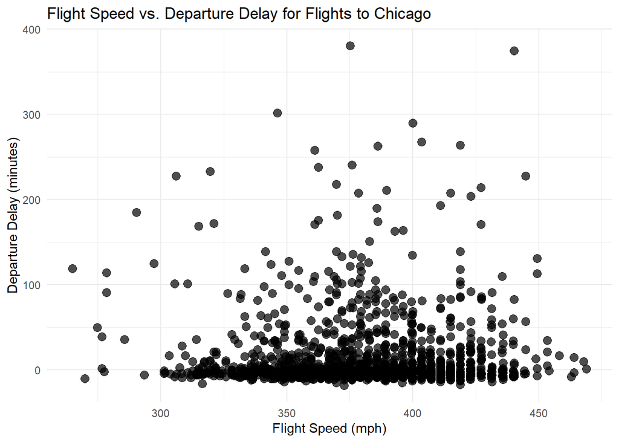

```r
ggplot(flights_to_ORD, aes(x = speed, y = dep_delay)) +
  geom_point(alpha = 0.7, size = 3) +
  labs(title = "Flight Speed vs. Departure Delay for Flights to Chicago",
       x = "Flight Speed (mph)",
       y = "Departure Delay (minutes)") +
  theme_minimal()
```

Try as I might, I couldn’t find any clear correlation between the departure delay and the flight speed. The only plot structure that made sense to me was a scatterplot, given the amount of data, I tried using a logscale for both of the axes (and tried both cases where only one has a logscale), and it still looked random. Therefore, I simply left it as a linear scale. I do see, though, that a lot of the data seems to be clustered around the bottom-middle of the graph (around 300-400 mph and 0 departure delay).

## ———- 2: Gapminder Data ———-

## ———- 2.1: Descriptive Stats ———-

## 2.1.1

```r
gapminder <- read_delim("C:/Users/xuz-t/OneDrive/Documents/INFO_201_Scripts/PS5/data/gapminder.csv")
gapminder_dims <- dim(gapminder)
print(gapminder_dims)
```

```
## [1] 13055    25
```

There are 13055 rows and 25 columns in this data.

## 2.1.2

```r
head(gapminder)
```

```
## # A tibble: 6 × 25
##   iso3  name  iso2  region   `sub-region`            `intermediate-region`  time
##   <chr> <chr> <chr> <chr>    <chr>                   <chr>                 <dbl>
## 1 ABW   Aruba AW    Americas Latin America and the … Caribbean              1960
## 2 ABW   Aruba AW    Americas Latin America and the … Caribbean              1961
## 3 ABW   Aruba AW    Americas Latin America and the … Caribbean              1962
## 4 ABW   Aruba AW    Americas Latin America and the … Caribbean              1963
## 5 ABW   Aruba AW    Americas Latin America and the … Caribbean              1964
## 6 ABW   Aruba AW    Americas Latin America and the … Caribbean              1965
## # ℹ 18 more variables: totalPopulation <dbl>, fertilityRate <dbl>,
## #   lifeExpectancy <dbl>, childMortality <dbl>, youthFemaleLiteracy <dbl>,
## #   youthMaleLiteracy <dbl>, adultLiteracy <dbl>, GDP_PC <dbl>,
## #   accessElectricity <dbl>, agriculturalLand <dbl>, agricultureTractors <dbl>,
## #   cerealProduction <dbl>, fertilizerHa <dbl>, co2 <dbl>,
## #   greenhouseGases <dbl>, co2_PC <dbl>, pm2.5_35 <dbl>, battleDeaths <dbl>
```

These is a sneakpeek of the gapminder dataset. It looks good.

## 2.1.3

```r
num_unique_iso3 <- gapminder %>% pull(iso3) %>% unique() %>% length()
num_unique_iso2 <- gapminder %>% pull(iso2) %>% unique() %>% length()
num_unique_name <- gapminder %>% pull(name) %>% unique() %>% length()
cat(num_unique_iso3, "\n")
```

```
## 253
```

```r
cat(num_unique_iso2, "\n")
```

```
## 249
```

```r
cat(num_unique_name)
```

```
## 250
```

According to iso3, there are 253 countries. According to iso2, there are 249 countries. According to the number of unique names, there are 250 countries.

## 2.1.4

```r
nonunique_names_iso2 <- gapminder %>%
  distinct(name, iso2, .keep_all = TRUE) %>%
  group_by(iso2) %>%
  summarise(name_counts = n(), unique_names = toString(unique(name))) %>%
  filter(name_counts > 1)
nonunique_iso3_names <- gapminder %>%
  distinct(name, iso3, .keep_all = TRUE) %>%
  group_by(name) %>%
  summarise(iso3_counts = n(), unique_iso3 = toString(unique(iso3))) %>%
  filter(iso3_counts > 1)
print(nonunique_names_iso2)
```

```
## # A tibble: 1 × 3
##   iso2  name_counts unique_names
##   <chr>       <int> <chr>
## 1 <NA>            2 NA, Namibia
```

```r
print(nonunique_iso3_names)
```

```
## # A tibble: 1 × 3
##   name  iso3_counts unique_iso3
##   <chr>       <int> <chr>
## 1 <NA>            4 CHANISL, GBM, KOS, NLD_CURACAO
```

The iso2 with non-unique names is NA, which is the iso2 entry for both the NA entry and Namibia. The iso3’s with non-unique names are CHANISL, GBM, KOS, and NLD_CURACAO, all of which correspond to an NA entry.

### ———- 2.2: CO2 Emissions ———-

## 2.2.1

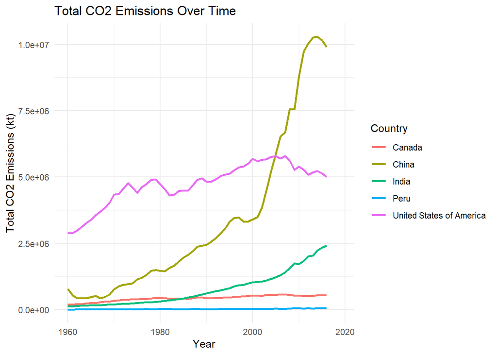

```r
selected_countries <- c("United States of America", "China", "India", "Canada", "Peru")
selected_data <- gapminder[gapminder$name %in% selected_countries, ]
ggplot(selected_data, aes(x = time, y = co2)) +
  geom_line(aes(color = name), size = 1, na.rm = TRUE) +
  labs(title = "Total CO2 Emissions Over Time",
       x = "Year",
       y = "Total CO2 Emissions (kt)",
       color = "Country") +
  theme_minimal()
```

I see that China’s CO2 emission has had rapid growth, India’s has had some growth, while all the other countries have stayed relatively the same, relative to their already existing amounts of CO2 emissions.

## 2.2.2

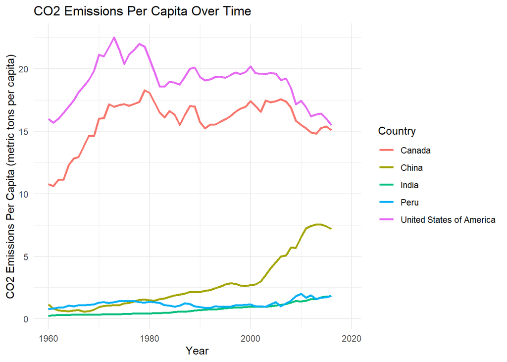

```r
ggplot(selected_data, aes(x = time, y = co2_PC)) +
  geom_line(aes(color = name), size = 1, na.rm = TRUE) +
  labs(title = "CO2 Emissions Per Capita Over Time",
       x = "Year",
       y = "CO2 Emissions Per Capita (metric tons per capita)",
       color = "Country") +
  theme_minimal()
```

I see that while China’s CO2 emission per capita has grown, the US’s and Canada’s emission per capita is by far the greatest.

## 2.2.3

```r
filtered_data <- gapminder %>% filter(time %in% c(1960, 2016))
average_co2_pc <- filtered_data %>%
  group_by(region, time) %>%
  summarise(avg_co2_pc = mean(co2_PC, na.rm = TRUE), .groups = 'drop')
average_co2_pc <- na.omit(average_co2_pc)
print(average_co2_pc)
```

```
## # A tibble: 10 × 3
##    region    time avg_co2_pc
##    <chr>    <dbl>      <dbl>
##  1 Africa    1960      0.291
##  2 Africa    2016      1.20
##  3 Americas  1960      7.15
##  4 Americas  2016      4.80
##  5 Asia      1960      1.74
##  6 Asia      2016      6.47
##  7 Europe    1960      5.77
##  8 Europe    2016      6.64
##  9 Oceania   1960      2.73
## 10 Oceania   2016      4.57
```

I see a couple of things - Africa’s is low, America’s has dropped significantly between 1960 and 2016, while Asia’s has significantly grown from 1960 to 2016.

## 2.2.4

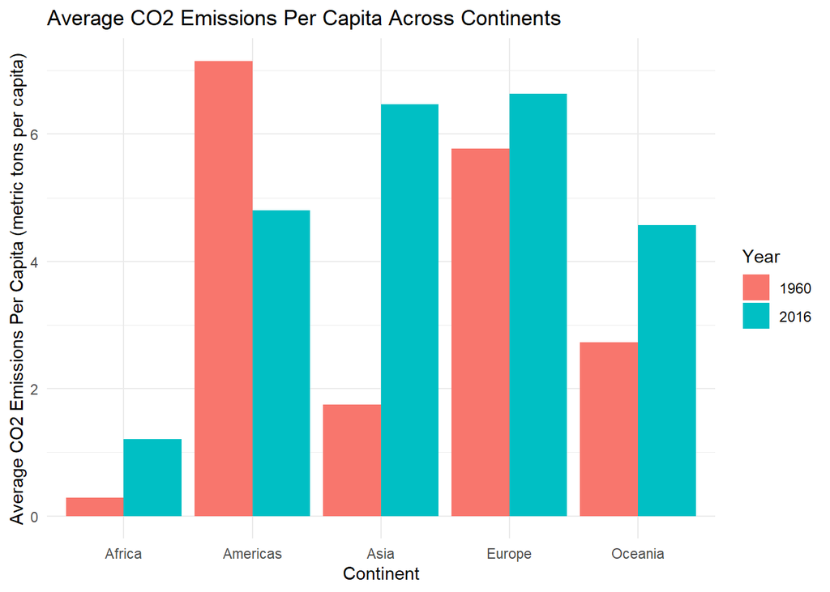

```r
ggplot(average_co2_pc, aes(x = region, y = avg_co2_pc, fill = factor(time))) +
  geom_bar(stat = "identity", position = "dodge") +
  labs(title = "Average CO2 Emissions Per Capita Across Continents",
       x = "Continent",
       y = "Average CO2 Emissions Per Capita (metric tons per capita)",
       fill = "Year") +
  theme_minimal()
```

This data visually confirms the conclusions that I drew from the tabular data.

### ———- 2.3: Life Expectancy & Fertility ———-

## 2.3.1

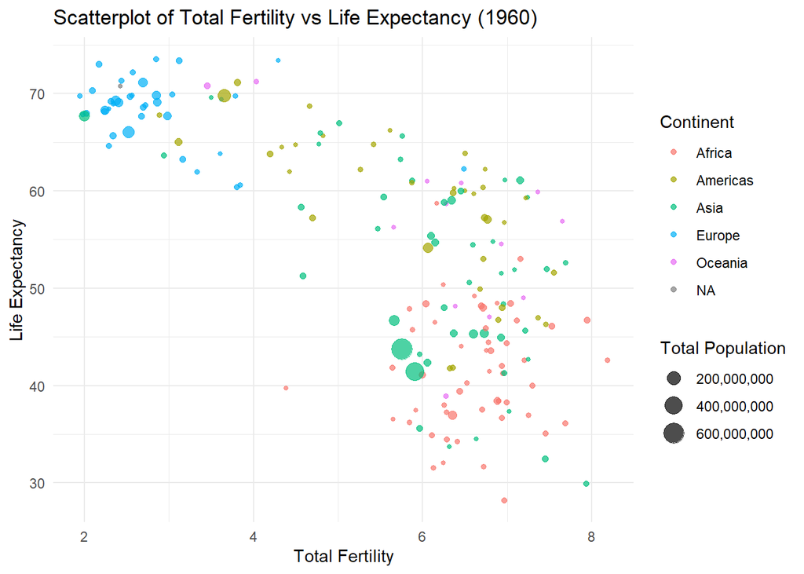

```r
data_1960 <- gapminder[gapminder$time == 1960, ]
ggplot(data_1960, aes(x = fertilityRate, y = lifeExpectancy, size = totalPopulation, color = region)) +
  geom_point(alpha = 0.7, na.rm = TRUE) +
  scale_size_continuous(labels = scales::comma) +
  labs(title = "Scatterplot of Total Fertility vs Life Expectancy (1960)",
       x = "Total Fertility",
       y = "Life Expectancy",
       size = "Total Population",
       color = "Continent") +
  theme_minimal()
```

I see that there is generally a negative correlation between Life Expectancy and Total Fertility. Furthermore, Europe seems to dominate the top-left of the graph, while Africa dominates the bottom right area of the graph.

## 2.3.2

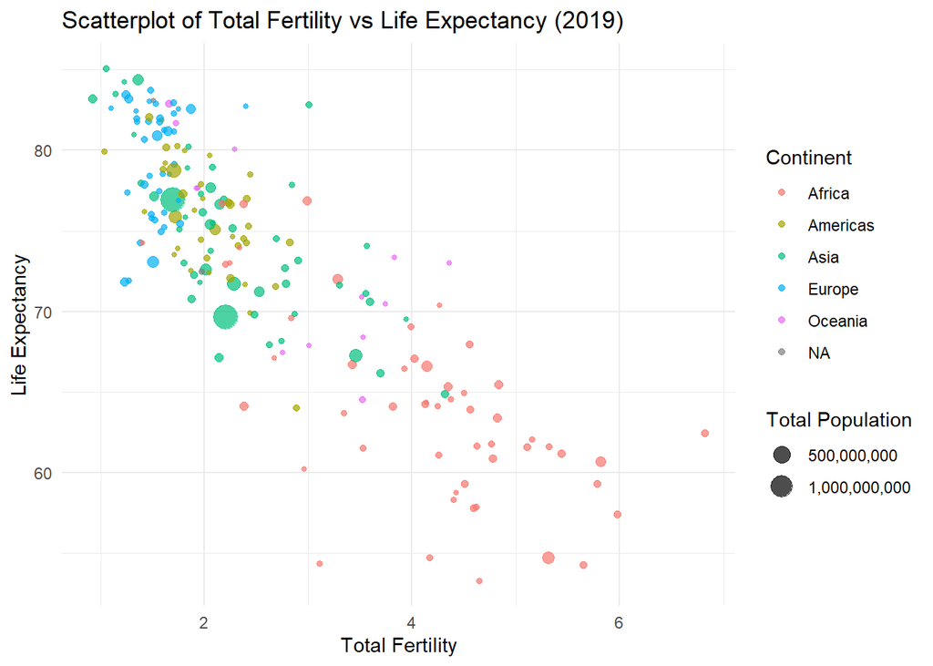

```r
data_2019 <- gapminder[gapminder$time == 2019, ]
ggplot(data_2019, aes(x = fertilityRate, y = lifeExpectancy, size = totalPopulation, color = region)) +
  geom_point(alpha = 0.7, na.rm = TRUE) +
  scale_size_continuous(labels = scales::comma) +
  labs(title = "Scatterplot of Total Fertility vs Life Expectancy (2019)",
       x = "Total Fertility",
       y = "Life Expectancy",
       size = "Total Population",
       color = "Continent") +
  theme_minimal()
```

## 2.3.3

In comparison to 1960, both life expectancy has risen and fertility rates have generally gone down. Both America and Asia have drastically moved to the left, and Africa has spread away from the bottom right corner of the graph. The world developed in a way where life expectancy has increased, necessitating less births for the hope that they grow to adults.

## 2.3.4

```r
data_1960_2019 <- gapminder %>% filter(time %in% c(1960, 2019))
average_life_expectancy <- data_1960_2019 %>%
  group_by(region, time) %>%
  summarise(avg_life_expectancy = mean(lifeExpectancy, na.rm = TRUE), .groups = 'drop')
average_life_expectancy <- na.omit(average_life_expectancy)
print(average_life_expectancy)
```

```
## # A tibble: 10 × 3
##    region    time avg_life_expectancy
##    <chr>    <dbl>               <dbl>
##  1 Africa    1960                41.5
##  2 Africa    2019                64.1
##  3 Americas  1960                58.6
##  4 Americas  2019                75.8
##  5 Asia      1960                51.6
##  6 Asia      2019                74.6
##  7 Europe    1960                68.3
##  8 Europe    2019                79.4
##  9 Oceania   1960                56.4
## 10 Oceania   2019                73.5
```

Yes, this information fits with what I saw on the previous figures.

## 2.3.5

```r
growth <- average_life_expectancy[average_life_expectancy$time == 2019, ]$avg_life_expectancy -
          average_life_expectancy[average_life_expectancy$time == 1960, ]$avg_life_expectancy
growth_df <- data.frame(Continent = unique(average_life_expectancy$region),
                        Growth = growth)
print(growth_df)
```

```
##   Continent   Growth
## 1    Africa 22.64414
## 2  Americas 17.18555
## 3      Asia 22.96808
## 4    Europe 11.07460
## 5   Oceania 17.13214
```

## 2.3.6

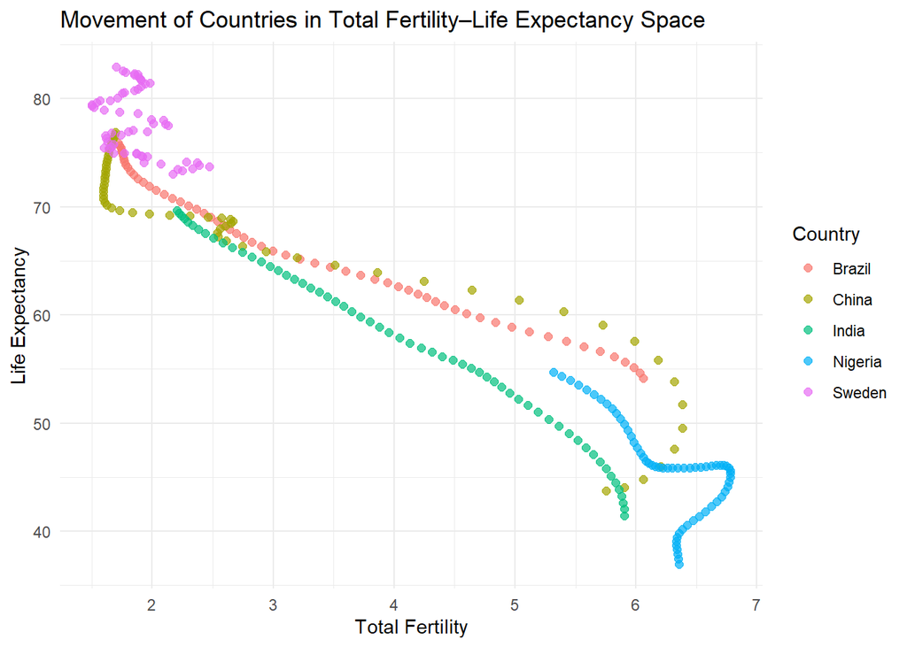

```r
selected_countries <- c("United States", "Sweden", "China", "India", "Brazil", "Nigeria")
data_selected_countries <- gapminder[gapminder$name %in% selected_countries, ]
ggplot(data_selected_countries, aes(x = fertilityRate, y = lifeExpectancy, color = name, group = name)) +
  geom_point(alpha = 0.7, size = 2) +
  labs(title = "Movement of Countries in Total Fertility–Life Expectancy Space",
       x = "Total Fertility",
       y = "Life Expectancy",
       color = "Country") +
  theme_minimal()
```

## 2.3.7

```r
data_1960_ranked <- data_1960 %>%
  arrange(desc(lifeExpectancy)) %>%
  mutate(lifeExpectancyRank = row_number())
rank_1960_usa <- data_1960_ranked %>%
  filter(name == "United States of America")
data_2019_ranked <- data_2019 %>%
  arrange(desc(lifeExpectancy)) %>%
  mutate(lifeExpectancyRank = row_number())
rank_2019_usa <- data_2019_ranked %>%
  filter(name == "United States of America")

cat(rank_1960_usa$lifeExpectancyRank, "\n")
```

```
## 18
```

```r
cat(rank_2019_usa$lifeExpectancyRank, "\n")
```

```
## 47
```

The ranking of the US in life expectancy for 1960 was: 18 The ranking of the US in life expectancy for 2019 was: 47

I’ve spent about 10 hours on this assignment.